# Data Analyzation Project in R for Google Data Analyzation Course

Viktória Andor-Sikorszki

2024-11-02

[figure not shown]

# The business task

Bellabeat is a small company and the owners are motivated to make it to a larger player in the market, so they want to find new growth opportunities for their company. They want an analysis of device fitness data to gain insight into how consumers are using their smart devices.

The task is to analyze smart device usage data in order to gain insight into how consumers use non-Bellabeat smart devices. Then one Bellabeat product has to be selected to apply these insights to the presentation. Based on the insights the owners expect recommendations how they should develop their marketing strategy. The insights of the analysis has an effect on the investments in developing the products and how they want to position them on the market.

Key questions to answer with the analysis: 1. What are some trends in smart device usage? 2. How could these trends apply to Bellabeat customers? 3. How could these trends help influence Bellabeat marketing strategy?

Stakeholders: - The owners: * Urška Sršen, Bellabeat’s cofounder and Chief Creative Officer. She’s a creative and more visual person, so for she needs a comprehensive and clear visualization. * Sando Mur, Mathematician and Bellabeat’s cofounder; key member of the Bellabeat executive team. He makes decision on precise data and well-established data analysis. - Bellabeat marketing analytics team: A team of data analysts responsible for collecting, analyzing, and reporting data that helps guide Bellabeat’s marketing strategy.

# Date sources

FitBit Fitness Tracker Data (kaggle.com) This dataset generated by respondents to a distributed survey via Amazon Mechanical Turk between 03.12.2016-05.12.2016. Thirty eligible Fitbit users consented to the submission of personal tracker data, including minute-level output for physical activity, heart rate, and sleep monitoring. Individual reports can be parsed by export session ID (column A) or timestamp (column B). Variation between output represents use of different types of Fitbit trackers and individual tracking behaviors / preferences. [https://www.kaggle.com/datasets/arashnic/fitbit] Downloaded: Sunday, March 10, 2024, 14:57:57

# Verifying the reliability of the data

The data source is reliable and original as data come from volunteer Fitbit usesrs, who allowed to track their activity. The data source is comprehensive, because it contains a lot of data about a user’s daily activity: weight, BMI, steps, intensity of activity, burned calories and sleeping. The data are from an exact time period between 03.12.2016-05.12.2016 and as they are exact measured data for a given point of time, they haven’t changed since then. The data source is maintained on Kaggle monthly.

# Structure of the data

The data are organized into data tables according to day and measured type of data: activity, heartrate, steps, sleeping. There are 29 tables with user’s activity data in .csv format. Some of the data are available in wide and narrow version as well. The file format allows to process and analyze the data in spreadsheet, from data base by SQL or by programming in R. After formatting, sorting and filtering of the data I found that there are false date data and some exceling value in the data set. Data cleaning

# Cleaning the data

The following cleaning steps were executed in spreadsheets and are applied for all tables in the dataset:

1. Merging tables from different folders with same content.
1. create variable for the tables using read_csv()
2. merge tables tables by rbind() function where the data are split into more tables
3. check the number of rows with summary() and preview with head()
2. Renaming colnames where needed
3. Correcting dates by substituting the correct month number by using library stringr
4. Formatting data
5. Removing duplicates by distinct() dplyr
6. Finding and removing missing data
7. Checking and removing outliers
8. Cross-hecking data validity by summary()
9. Saving the clean data in csv by write.csv

Cleaning code and clean tables are attached to the documentation.

# Analyzing and visualizing the data

## Daily Activities

```r
# reading data

dailyActivities_clean <- read.csv("~/bellabeat_project/Clean_tables/dailyActivities_clean.csv")

# explore data
##glimpse(dailyActivities_clean)
dailyActivities_clean$Id <- as.character(dailyActivities_clean$Id)
##skimr::skim(dailyActivities_clean)
number_of_ids <- n_distinct(dailyActivities_clean$Id)
print(number_of_ids)
```

```
## [1] 35
```

There were 30 participants in the study but from the data we can see that 35 fitbits were used, which means that only a few users have more equipment in use. We can assume that the users prefer equipment that can be used more widely.

The observation took place between 03.12.2016 and 05.12.2016 and the data frame contains only quantitative data based on user entries.

### Number of daily entries

The collecting of the data took place between 3rd and 5th December 2016. Based on the data the users used the fitbit on the second day the most.

```r
total_daily_entries <- dailyActivities_clean %>% group_by(ActivityDate) %>%  summarize(count_by_ActivityDate = n())
kable(total_daily_entries)
```

| ActivityDate | count_by_ActivityDate |
| --- | --- |
| 2016-12-03 | 64 |
| 2016-12-04 | 933 |
| 2016-12-05 | 314 |

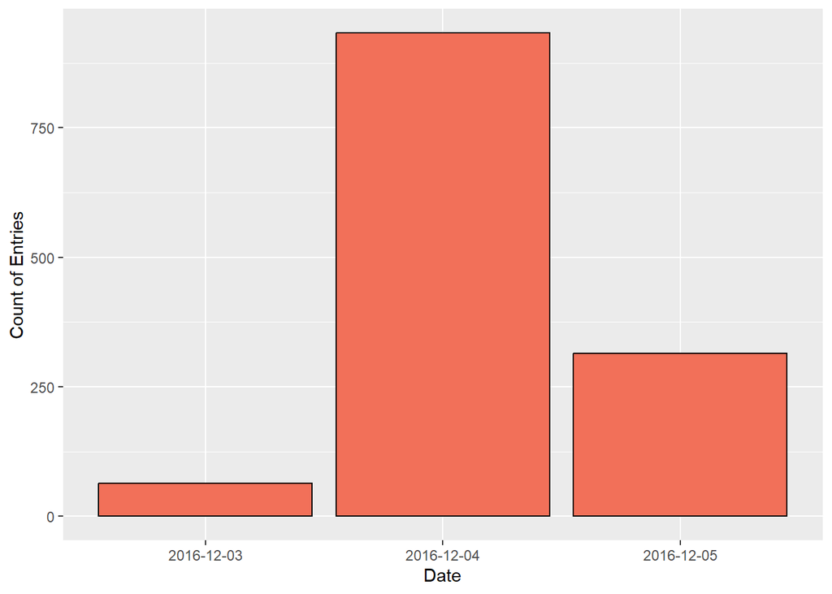

```r
chart_1 <- ggplot(total_daily_entries, aes(x = ActivityDate, y = count_by_ActivityDate)) +
  geom_col(fill="#f27059", colour="black") + labs(x='Date', y='Count of Entries')
ggsave("total_daily_entries.jpeg", plot=chart_1, path = '~/bellabeat_project/Figures')
chart_1
```

### Number of entries by Id

```r
total_entries_by_id <- dailyActivities_clean %>% group_by(Id) %>% summarize(count_by_id = n())
sorted_total_entries_by_id <- total_entries_by_id[order(total_entries_by_id$count_by_id, decreasing = TRUE),]
sorted_total_entries_by_id %>% kable()
```

| Id | count_by_id |
| --- | --- |
| 4020332650 | 52 |
| 1503960366 | 50 |
| 1624580081 | 50 |
| 4445114986 | 46 |
| 4702921684 | 46 |
| 6962181067 | 45 |
| 2022484408 | 43 |
| 2026352035 | 43 |
| 2873212765 | 43 |
| 4319703577 | 43 |
| 4558609924 | 43 |
| 5553957443 | 43 |
| 7086361926 | 43 |
| 8378563200 | 43 |
| 8877689391 | 43 |
| 3977333714 | 42 |
| 8053475328 | 42 |
| 1644430081 | 40 |
| 2320127002 | 40 |
| 5577150313 | 40 |
| 8583815059 | 39 |
| 7007744171 | 38 |
| 1844505072 | 36 |
| 6117666160 | 35 |
| 4388161847 | 34 |
| 8792009665 | 34 |
| 1927972279 | 33 |
| 2347167796 | 33 |
| 3372868164 | 30 |
| 6290855005 | 30 |
| 6775888955 | 27 |
| 8253242879 | 26 |
| 4057192912 | 25 |
| 6391747486 | 6 |
| 2891001357 | 5 |

```r
cat("Average number of entries: ", mean(total_entries_by_id$count_by_id))
```

```
## Average number of entries:  37.45714
```

```r
cat("Median of entries: ", median(total_entries_by_id$count_by_id))
```

```
## Median of entries:  40
```

```r
cat("Mode of entries: ", Mode(total_entries_by_id$count_by_id))
```

```
## Mode of entries:  43
```

### Number of daily entries by Id

```r
daily_entries_by_id <- dailyActivities_clean %>% group_by(Id, ActivityDate) %>%  summarize(count_by_Id = n())
kable(daily_entries_by_id)
```

| Id | ActivityDate | count_by_Id |
| --- | --- | --- |
| 1503960366 | 2016-12-03 | 7 |
| 1503960366 | 2016-12-04 | 31 |
| 1503960366 | 2016-12-05 | 12 |
| 1624580081 | 2016-12-03 | 7 |
| 1624580081 | 2016-12-04 | 31 |
| 1624580081 | 2016-12-05 | 12 |
| 1644430081 | 2016-12-04 | 29 |
| 1644430081 | 2016-12-05 | 11 |
| 1844505072 | 2016-12-04 | 28 |
| 1844505072 | 2016-12-05 | 8 |
| 1927972279 | 2016-12-04 | 25 |
| 1927972279 | 2016-12-05 | 8 |
| 2022484408 | 2016-12-04 | 31 |
| 2022484408 | 2016-12-05 | 12 |
| 2026352035 | 2016-12-04 | 31 |
| 2026352035 | 2016-12-05 | 12 |
| 2320127002 | 2016-12-04 | 28 |
| 2320127002 | 2016-12-05 | 12 |
| 2347167796 | 2016-12-03 | 3 |
| 2347167796 | 2016-12-04 | 30 |
| 2873212765 | 2016-12-04 | 31 |
| 2873212765 | 2016-12-05 | 12 |
| 2891001357 | 2016-12-03 | 1 |
| 2891001357 | 2016-12-04 | 4 |
| 3372868164 | 2016-12-04 | 29 |
| 3372868164 | 2016-12-05 | 1 |
| 3977333714 | 2016-12-04 | 31 |
| 3977333714 | 2016-12-05 | 11 |
| 4020332650 | 2016-12-03 | 20 |
| 4020332650 | 2016-12-04 | 20 |
| 4020332650 | 2016-12-05 | 12 |
| 4057192912 | 2016-12-03 | 14 |
| 4057192912 | 2016-12-04 | 11 |
| 4319703577 | 2016-12-03 | 3 |
| 4319703577 | 2016-12-04 | 28 |
| 4319703577 | 2016-12-05 | 12 |
| 4388161847 | 2016-12-03 | 1 |
| 4388161847 | 2016-12-04 | 21 |
| 4388161847 | 2016-12-05 | 12 |
| 4445114986 | 2016-12-03 | 3 |
| 4445114986 | 2016-12-04 | 31 |
| 4445114986 | 2016-12-05 | 12 |
| 4558609924 | 2016-12-04 | 31 |
| 4558609924 | 2016-12-05 | 12 |
| 4702921684 | 2016-12-03 | 3 |
| 4702921684 | 2016-12-04 | 31 |
| 4702921684 | 2016-12-05 | 12 |
| 5553957443 | 2016-12-04 | 31 |
| 5553957443 | 2016-12-05 | 12 |
| 5577150313 | 2016-12-04 | 30 |
| 5577150313 | 2016-12-05 | 10 |
| 6117666160 | 2016-12-04 | 26 |
| 6117666160 | 2016-12-05 | 9 |
| 6290855005 | 2016-12-04 | 20 |
| 6290855005 | 2016-12-05 | 10 |
| 6391747486 | 2016-12-04 | 6 |
| 6775888955 | 2016-12-04 | 22 |
| 6775888955 | 2016-12-05 | 5 |
| 6962181067 | 2016-12-03 | 2 |
| 6962181067 | 2016-12-04 | 31 |
| 6962181067 | 2016-12-05 | 12 |
| 7007744171 | 2016-12-04 | 31 |
| 7007744171 | 2016-12-05 | 7 |
| 7086361926 | 2016-12-04 | 31 |
| 7086361926 | 2016-12-05 | 12 |
| 8053475328 | 2016-12-04 | 30 |
| 8053475328 | 2016-12-05 | 12 |
| 8253242879 | 2016-12-04 | 26 |
| 8378563200 | 2016-12-04 | 31 |
| 8378563200 | 2016-12-05 | 12 |
| 8583815059 | 2016-12-04 | 27 |
| 8583815059 | 2016-12-05 | 12 |
| 8792009665 | 2016-12-04 | 28 |
| 8792009665 | 2016-12-05 | 6 |
| 8877689391 | 2016-12-04 | 31 |
| 8877689391 | 2016-12-05 | 12 |

### Number of usage days by Id

```r
usage_days_by_id <- daily_entries_by_id %>% group_by(Id) %>%  summarize(count_activity_dates = n())
kable(usage_days_by_id)
```

| Id | count_activity_dates |
| --- | --- |
| 1503960366 | 3 |
| 1624580081 | 3 |
| 1644430081 | 2 |
| 1844505072 | 2 |
| 1927972279 | 2 |
| 2022484408 | 2 |
| 2026352035 | 2 |
| 2320127002 | 2 |
| 2347167796 | 2 |
| 2873212765 | 2 |
| 2891001357 | 2 |
| 3372868164 | 2 |
| 3977333714 | 2 |
| 4020332650 | 3 |
| 4057192912 | 2 |
| 4319703577 | 3 |
| 4388161847 | 3 |
| 4445114986 | 3 |
| 4558609924 | 2 |
| 4702921684 | 3 |
| 5553957443 | 2 |
| 5577150313 | 2 |
| 6117666160 | 2 |
| 6290855005 | 2 |
| 6391747486 | 1 |
| 6775888955 | 2 |
| 6962181067 | 3 |
| 7007744171 | 2 |
| 7086361926 | 2 |
| 8053475328 | 2 |
| 8253242879 | 1 |
| 8378563200 | 2 |
| 8583815059 | 2 |
| 8792009665 | 2 |
| 8877689391 | 2 |

```r
cat("Average number of usage days: ", mean(usage_days_by_id$count_activity_dates))
```

```
## Average number of usage days:  2.171429
```

```r
cat("Median of usage days: ", median(usage_days_by_id$count_activity_dates))
```

```
## Median of usage days:  2
```

```r
cat("Mode of usage days: ", Mode(usage_days_by_id$count_activity_dates))
```

```
## Mode of usage days:  2
```

The most users used the device for 2 days, the average usage was 2,17 days.

### Distribution of users per day

```r
distribution_ids_per_usage_days <- usage_days_by_id %>% group_by(count_activity_dates) %>% summarize(count_id = n())
distribution_ids_per_usage_days$percent_of_users <- percent(distribution_ids_per_usage_days$count_id / 35)
kable(distribution_ids_per_usage_days)
```

| count_activity_dates | count_id | percent_of_users |
| --- | --- | --- |
| 1 | 2 | 6% |
| 2 | 25 | 71% |
| 3 | 8 | 23% |

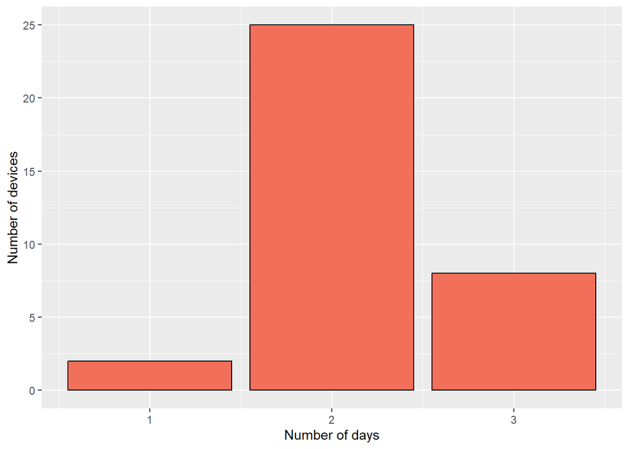

```r
chart_2 <- ggplot(distribution_ids_per_usage_days, aes(count_activity_dates, count_id)) + geom_col(fill="#f27059", colour="black") + labs(x='Number of days', y='Number of devices')
ggsave("users_per_day.jpeg", plot=chart_2, path = '~/bellabeat_project/Figures')
chart_2
```

### Sums by Id

```r
sums_by_id <-
dailyActivities_clean %>% group_by(Id) %>%
  summarize(count_by_id=  n(), total_steps_by_id = sum(TotalSteps), total_distance_by_id= sum(TotalDistance), total_tracker_distance_by_id = sum(TrackerDistance), total_logged_activities_distance_by_id= sum(LoggedActivitiesDistance), total_very_active_distance_by_id= sum(VeryActiveDistance), total_moderately_active_distance_by_id= sum(ModeratelyActiveDistance), total_light_active_distance_by_id = sum(LightActiveDistance), total_sedentary_active_distance_by_id = sum(SedentaryActiveDistance), total_very_active_minutes_by_id= sum(VeryActiveMinutes), total_fairly_active_minutes_by_id = sum(FairlyActiveMinutes), total_lightly_active_minutes_by_id =sum(LightlyActiveMinutes), total_sedentary_minutes_by_id = sum(SedentaryMinutes), total_calories_by_id= sum(Calories))
sums_by_id <- full_join(sums_by_id, usage_days_by_id, by='Id')
sums_by_id %>% kable()
```

| Id | count_by_id | total_steps_by_id | total_distance_by_id | total_tracker_distance_by_id | total_logged_activities_distance_by_id | total_very_active_distance_by_id | total_moderately_active_distance_by_id | total_light_active_distance_by_id | total_sedentary_active_distance_by_id | total_very_active_minutes_by_id | total_fairly_active_minutes_by_id | total_lightly_active_minutes_by_id | total_sedentary_minutes_by_id | total_calories_by_id | count_activity_dates |
| --- | --- | --- | --- | --- | --- | --- | --- | --- | --- | --- | --- | --- | --- | --- | --- |
| 1503960366 | 50 | 596789 | 386.64 | 386.64 | 0.000000 | 141.50 | 36.69 | 208.13 | 0.00 | 1881 | 895 | 11154 | 41680 | 90437 | 3 |
| 1624580081 | 50 | 258360 | 173.55 | 173.55 | 0.000000 | 30.10 | 11.70 | 131.34 | 0.29 | 283 | 191 | 7058 | 63278 | 71689 | 3 |
| 1644430081 | 40 | 311237 | 226.35 | 226.35 | 0.000000 | 33.24 | 48.83 | 144.07 | 0.20 | 435 | 1076 | 7631 | 45198 | 113503 | 2 |
| 1844505072 | 36 | 123669 | 81.77 | 81.77 | 0.000000 | 0.87 | 1.89 | 78.96 | 0.00 | 13 | 49 | 5481 | 39749 | 58740 | 2 |
| 1927972279 | 33 | 54570 | 37.80 | 37.80 | 0.000000 | 2.97 | 1.71 | 33.11 | 0.00 | 41 | 44 | 2536 | 37875 | 73773 | 2 |
| 2022484408 | 43 | 498589 | 355.90 | 355.90 | 0.000000 | 112.10 | 32.93 | 210.89 | 0.00 | 1606 | 870 | 11027 | 47197 | 107513 | 2 |
| 2026352035 | 43 | 213286 | 132.34 | 132.34 | 0.000000 | 0.19 | 0.35 | 131.76 | 0.00 | 3 | 8 | 9988 | 29282 | 64026 | 2 |
| 2320127002 | 40 | 183884 | 124.29 | 124.29 | 0.000000 | 4.26 | 3.57 | 116.37 | 0.00 | 53 | 93 | 7655 | 48494 | 67862 | 2 |
| 2347167796 | 33 | 318355 | 212.07 | 212.07 | 0.000000 | 31.99 | 38.26 | 141.80 | 0.00 | 420 | 717 | 8348 | 22627 | 67102 | 2 |
| 2873212765 | 43 | 313868 | 211.78 | 211.78 | 0.000000 | 24.92 | 11.69 | 174.97 | 0.18 | 498 | 262 | 12851 | 47656 | 79775 | 2 |
| 2891001357 | 5 | 6189 | 4.83 | 0.00 | 9.656064 | 0.00 | 0.00 | 4.83 | 0.00 | 0 | 660 | 1350 | 4479 | 12427 | 2 |
| 3372868164 | 30 | 198508 | 136.30 | 136.30 | 0.000000 | 20.03 | 4.20 | 111.66 | 0.36 | 301 | 117 | 9427 | 32402 | 57265 | 2 |
| 3977333714 | 42 | 433504 | 295.19 | 295.19 | 0.000000 | 58.47 | 98.96 | 137.10 | 0.00 | 713 | 2213 | 7726 | 29731 | 62187 | 2 |
| 4020332650 | 52 | 255135 | 183.01 | 183.01 | 0.000000 | 9.71 | 10.31 | 112.27 | 0.37 | 291 | 411 | 6557 | 57178 | 150592 | 3 |
| 4057192912 | 25 | 75743 | 55.90 | 56.47 | 0.055843 | 3.41 | 8.04 | 43.92 | 0.06 | 43 | 175 | 1796 | 32487 | 49270 | 2 |
| 4319703577 | 43 | 319181 | 214.73 | 214.73 | 0.000000 | 14.16 | 24.17 | 165.74 | 0.00 | 190 | 601 | 10076 | 32171 | 87099 | 3 |
| 4388161847 | 34 | 335232 | 260.19 | 260.19 | 0.000000 | 53.30 | 27.96 | 167.28 | 0.00 | 718 | 631 | 7110 | 29811 | 100962 | 3 |
| 4445114986 | 46 | 213089 | 144.22 | 144.22 | 0.000000 | 22.57 | 2.96 | 118.60 | 0.00 | 281 | 68 | 9491 | 38648 | 99389 | 3 |
| 4558609924 | 43 | 307662 | 203.38 | 203.38 | 0.000000 | 19.20 | 22.52 | 161.60 | 0.00 | 374 | 458 | 11832 | 46926 | 84993 | 2 |
| 4702921684 | 46 | 384885 | 312.30 | 312.30 | 0.000000 | 16.51 | 52.62 | 242.83 | 0.00 | 203 | 1066 | 11063 | 34660 | 134254 | 3 |
| 5553957443 | 43 | 367247 | 240.33 | 240.33 | 0.000000 | 63.53 | 31.17 | 145.55 | 0.00 | 1009 | 603 | 8592 | 28012 | 79776 | 2 |
| 5577150313 | 40 | 343823 | 257.33 | 257.33 | 0.000000 | 127.67 | 26.86 | 102.36 | 0.00 | 3520 | 1205 | 6168 | 28517 | 135273 | 2 |
| 6117666160 | 35 | 279794 | 211.85 | 211.85 | 0.000000 | 4.01 | 5.08 | 194.70 | 0.00 | 49 | 98 | 11073 | 26617 | 79817 | 2 |
| 6290855005 | 30 | 180018 | 136.13 | 136.13 | 0.000000 | 4.50 | 7.40 | 123.94 | 0.25 | 125 | 217 | 6989 | 34567 | 77901 | 2 |
| 6391747486 | 6 | 12032 | 9.67 | 0.91 | 8.754830 | 2.03 | 0.05 | 7.59 | 0.00 | 46 | 6 | 309 | 7037 | 10408 | 1 |
| 6775888955 | 27 | 115543 | 83.02 | 83.02 | 1.959596 | 26.92 | 20.58 | 34.91 | 0.00 | 465 | 828 | 2160 | 31426 | 65221 | 2 |
| 6962181067 | 45 | 480595 | 325.23 | 319.50 | 24.087105 | 86.24 | 54.75 | 183.90 | 0.31 | 1202 | 980 | 11240 | 29020 | 90692 | 3 |
| 7007744171 | 38 | 441533 | 314.68 | 295.41 | 89.436832 | 105.27 | 27.06 | 182.29 | 0.07 | 1343 | 618 | 10629 | 39447 | 97669 | 2 |
| 7086361926 | 43 | 363772 | 247.16 | 247.16 | 0.000000 | 104.57 | 30.63 | 111.30 | 0.06 | 1635 | 998 | 5674 | 37030 | 105681 | 2 |
| 8053475328 | 42 | 620950 | 483.07 | 483.07 | 0.000000 | 357.89 | 18.57 | 106.50 | 0.00 | 3573 | 422 | 6378 | 47847 | 123145 | 2 |
| 8253242879 | 26 | 151840 | 108.83 | 108.83 | 0.000000 | 49.31 | 16.61 | 42.85 | 0.04 | 460 | 328 | 2932 | 33488 | 45812 | 1 |
| 8378563200 | 43 | 367872 | 291.74 | 291.74 | 49.728723 | 101.19 | 22.41 | 168.11 | 0.00 | 2484 | 442 | 6866 | 30410 | 146808 | 2 |
| 8583815059 | 39 | 247518 | 193.10 | 193.10 | 0.000000 | 25.11 | 32.37 | 99.02 | 0.00 | 305 | 703 | 5384 | 49378 | 103823 | 2 |
| 8792009665 | 34 | 90897 | 58.18 | 58.18 | 0.000000 | 1.30 | 3.06 | 53.82 | 0.00 | 46 | 182 | 4247 | 31397 | 69975 | 2 |
| 8877689391 | 43 | 706246 | 578.69 | 578.69 | 0.000000 | 293.15 | 16.27 | 267.12 | 0.19 | 2850 | 489 | 10168 | 47053 | 147442 | 2 |

### Daily sums by Id

```r
daily_sums_by_id <-
dailyActivities_clean %>% group_by(Id, ActivityDate) %>%
  summarize(count_by_id=  n(), counttotal_steps_by_id = sum(TotalSteps), total_distance_by_id= sum(TotalDistance), total_tracker_distance_by_id = sum(TrackerDistance), total_logged_activities_distance_by_id= sum(LoggedActivitiesDistance), total_very_active_distance_by_id= sum(VeryActiveDistance), total_moderately_active_distance_by_id= sum(ModeratelyActiveDistance), total_light_active_distance_by_id = sum(LightActiveDistance), total_sedentary_active_distance_by_id = sum(SedentaryActiveDistance), total_very_active_minutes_by_id= sum(VeryActiveMinutes), total_fairly_active_minutes_by_id = sum(FairlyActiveMinutes), total_lightly_active_minutes_by_id =sum(LightlyActiveMinutes), total_sedentary_minutes_by_id = sum(SedentaryMinutes), total_calories_by_id= sum(Calories))

daily_sums_by_id %>% kable()
```

| Id | ActivityDate | count_by_id | counttotal_steps_by_id | total_distance_by_id | total_tracker_distance_by_id | total_logged_activities_distance_by_id | total_very_active_distance_by_id | total_moderately_active_distance_by_id | total_light_active_distance_by_id | total_sedentary_active_distance_by_id | total_very_active_minutes_by_id | total_fairly_active_minutes_by_id | total_lightly_active_minutes_by_id | total_sedentary_minutes_by_id | total_calories_by_id |
| --- | --- | --- | --- | --- | --- | --- | --- | --- | --- | --- | --- | --- | --- | --- | --- |
| 1503960366 | 2016-12-03 | 7 | 89847 | 58.99 | 58.99 | 0.000000 | 24.15 | 4.23 | 30.58 | 0.00 | 308 | 107 | 1676 | 5834 | 13444 |
| 1503960366 | 2016-12-04 | 31 | 370130 | 239.48 | 239.48 | 0.000000 | 85.42 | 21.90 | 131.91 | 0.00 | 1135 | 543 | 6910 | 25615 | 56483 |
| 1503960366 | 2016-12-05 | 12 | 136812 | 88.17 | 88.17 | 0.000000 | 31.93 | 10.56 | 45.64 | 0.00 | 438 | 245 | 2568 | 10231 | 20510 |
| 1624580081 | 2016-12-03 | 7 | 14248 | 9.27 | 9.27 | 0.000000 | 0.51 | 0.27 | 8.42 | 0.03 | 7 | 4 | 669 | 9400 | 9440 |
| 1624580081 | 2016-12-04 | 31 | 176111 | 115.16 | 115.16 | 0.000000 | 6.81 | 6.65 | 101.48 | 0.17 | 83 | 118 | 4836 | 38856 | 44666 |
| 1624580081 | 2016-12-05 | 12 | 68001 | 49.12 | 49.12 | 0.000000 | 22.78 | 4.78 | 21.44 | 0.09 | 193 | 69 | 1553 | 15022 | 17583 |
| 1644430081 | 2016-12-04 | 29 | 234803 | 170.76 | 170.76 | 0.000000 | 24.34 | 40.68 | 105.59 | 0.11 | 319 | 891 | 5569 | 33514 | 83416 |
| 1644430081 | 2016-12-05 | 11 | 76434 | 55.59 | 55.59 | 0.000000 | 8.90 | 8.15 | 38.48 | 0.09 | 116 | 185 | 2062 | 11684 | 30087 |
| 1844505072 | 2016-12-04 | 28 | 112676 | 74.51 | 74.51 | 0.000000 | 0.87 | 1.63 | 71.95 | 0.00 | 13 | 42 | 5013 | 30206 | 47608 |
| 1844505072 | 2016-12-05 | 8 | 10993 | 7.26 | 7.26 | 0.000000 | 0.00 | 0.26 | 7.01 | 0.00 | 0 | 7 | 468 | 9543 | 11132 |
| 1927972279 | 2016-12-04 | 25 | 41363 | 28.66 | 28.66 | 0.000000 | 0.07 | 1.38 | 27.21 | 0.00 | 1 | 35 | 2112 | 27302 | 56266 |
| 1927972279 | 2016-12-05 | 8 | 13207 | 9.14 | 9.14 | 0.000000 | 2.90 | 0.33 | 5.90 | 0.00 | 40 | 9 | 424 | 10573 | 17507 |
| 2022484408 | 2016-12-04 | 31 | 373033 | 267.53 | 267.53 | 0.000000 | 84.98 | 23.97 | 158.63 | 0.00 | 1172 | 638 | 8123 | 33931 | 78406 |
| 2022484408 | 2016-12-05 | 12 | 125556 | 88.37 | 88.37 | 0.000000 | 27.12 | 8.96 | 52.26 | 0.00 | 434 | 232 | 2904 | 13266 | 29107 |
| 2026352035 | 2016-12-04 | 31 | 131607 | 81.64 | 81.64 | 0.000000 | 0.19 | 0.35 | 81.08 | 0.00 | 3 | 8 | 6357 | 21630 | 44847 |
| 2026352035 | 2016-12-05 | 12 | 81679 | 50.70 | 50.70 | 0.000000 | 0.00 | 0.00 | 50.68 | 0.00 | 0 | 0 | 3631 | 7652 | 19179 |
| 2320127002 | 2016-12-04 | 28 | 129812 | 87.84 | 87.84 | 0.000000 | 2.41 | 2.60 | 82.76 | 0.00 | 28 | 66 | 5378 | 34025 | 47670 |
| 2320127002 | 2016-12-05 | 12 | 54072 | 36.45 | 36.45 | 0.000000 | 1.85 | 0.97 | 33.61 | 0.00 | 25 | 27 | 2277 | 14469 | 20192 |
| 2347167796 | 2016-12-03 | 3 | 27565 | 18.36 | 18.36 | 0.000000 | 1.93 | 5.18 | 11.24 | 0.00 | 23 | 93 | 713 | 1928 | 6157 |
| 2347167796 | 2016-12-04 | 30 | 290790 | 193.71 | 193.71 | 0.000000 | 30.06 | 33.08 | 130.56 | 0.00 | 397 | 624 | 7635 | 20699 | 60945 |
| 2873212765 | 2016-12-04 | 31 | 224762 | 151.74 | 151.74 | 0.000000 | 18.41 | 8.72 | 124.48 | 0.12 | 356 | 192 | 9174 | 34717 | 57238 |
| 2873212765 | 2016-12-05 | 12 | 89106 | 60.04 | 60.04 | 0.000000 | 6.51 | 2.97 | 50.49 | 0.06 | 142 | 70 | 3677 | 12939 | 22537 |
| 2891001357 | 2016-12-03 | 1 | 0 | 0.00 | 0.00 | 0.000000 | 0.00 | 0.00 | 0.00 | 0.00 | 0 | 0 | 0 | 1440 | 1920 |
| 2891001357 | 2016-12-04 | 4 | 6189 | 4.83 | 0.00 | 9.656064 | 0.00 | 0.00 | 4.83 | 0.00 | 0 | 660 | 1350 | 3039 | 10507 |
| 3372868164 | 2016-12-04 | 29 | 195431 | 134.20 | 134.20 | 0.000000 | 20.03 | 4.20 | 109.57 | 0.36 | 301 | 117 | 9255 | 31560 | 56028 |
| 3372868164 | 2016-12-05 | 1 | 3077 | 2.10 | 2.10 | 0.000000 | 0.00 | 0.00 | 2.09 | 0.00 | 0 | 0 | 172 | 842 | 1237 |
| 3977333714 | 2016-12-04 | 31 | 301047 | 205.00 | 205.00 | 0.000000 | 42.37 | 57.19 | 105.12 | 0.00 | 522 | 1311 | 5945 | 22286 | 45824 |
| 3977333714 | 2016-12-05 | 11 | 132457 | 90.19 | 90.19 | 0.000000 | 16.10 | 41.77 | 31.98 | 0.00 | 191 | 902 | 1781 | 7445 | 16363 |
| 4020332650 | 2016-12-03 | 20 | 115384 | 82.77 | 82.77 | 0.000000 | 2.34 | 1.70 | 30.46 | 0.05 | 74 | 102 | 1887 | 23589 | 63432 |
| 4020332650 | 2016-12-04 | 20 | 82056 | 58.85 | 58.85 | 0.000000 | 3.77 | 5.56 | 48.37 | 0.15 | 161 | 197 | 2765 | 21500 | 54593 |
| 4020332650 | 2016-12-05 | 12 | 57695 | 41.39 | 41.39 | 0.000000 | 3.60 | 3.05 | 33.44 | 0.17 | 56 | 112 | 1905 | 12089 | 32567 |
| 4057192912 | 2016-12-03 | 14 | 39871 | 29.44 | 30.01 | 0.055843 | 3.00 | 1.99 | 24.16 | 0.06 | 37 | 42 | 984 | 19097 | 28473 |
| 4057192912 | 2016-12-04 | 11 | 35872 | 26.46 | 26.46 | 0.000000 | 0.41 | 6.05 | 19.76 | 0.00 | 6 | 133 | 812 | 13390 | 20797 |
| 4319703577 | 2016-12-03 | 3 | 22830 | 15.32 | 15.32 | 0.000000 | 0.73 | 1.37 | 13.21 | 0.00 | 11 | 37 | 690 | 2510 | 6228 |
| 4319703577 | 2016-12-04 | 28 | 201960 | 135.67 | 135.67 | 0.000000 | 8.48 | 16.02 | 100.71 | 0.00 | 119 | 397 | 6285 | 22008 | 56651 |
| 4319703577 | 2016-12-05 | 12 | 94391 | 63.74 | 63.74 | 0.000000 | 4.95 | 6.78 | 51.82 | 0.00 | 60 | 167 | 3101 | 7653 | 24220 |
| 4388161847 | 2016-12-03 | 1 | 0 | 0.00 | 0.00 | 0.000000 | 0.00 | 0.00 | 0.00 | 0.00 | 0 | 0 | 0 | 1440 | 1878 |
| 4388161847 | 2016-12-04 | 21 | 192846 | 148.95 | 148.95 | 0.000000 | 20.84 | 15.53 | 100.90 | 0.00 | 321 | 344 | 4320 | 18810 | 61628 |
| 4388161847 | 2016-12-05 | 12 | 142386 | 111.24 | 111.24 | 0.000000 | 32.46 | 12.43 | 66.38 | 0.00 | 397 | 287 | 2790 | 9561 | 37456 |
| 4445114986 | 2016-12-03 | 3 | 9707 | 6.51 | 6.51 | 0.000000 | 0.00 | 0.00 | 6.51 | 0.00 | 0 | 0 | 556 | 2870 | 6269 |
| 4445114986 | 2016-12-04 | 31 | 140952 | 95.44 | 95.44 | 0.000000 | 13.38 | 0.98 | 81.03 | 0.00 | 162 | 22 | 6465 | 27180 | 66997 |
| 4445114986 | 2016-12-05 | 12 | 62430 | 42.27 | 42.27 | 0.000000 | 9.19 | 1.98 | 31.06 | 0.00 | 119 | 46 | 2470 | 8598 | 26123 |
| 4558609924 | 2016-12-04 | 31 | 223397 | 147.68 | 147.68 | 0.000000 | 12.75 | 15.68 | 119.19 | 0.00 | 229 | 310 | 8597 | 33894 | 61122 |
| 4558609924 | 2016-12-05 | 12 | 84265 | 55.70 | 55.70 | 0.000000 | 6.45 | 6.84 | 42.41 | 0.00 | 145 | 148 | 3235 | 13032 | 23871 |
| 4702921684 | 2016-12-03 | 3 | 21052 | 17.08 | 17.08 | 0.000000 | 0.58 | 0.82 | 15.67 | 0.00 | 7 | 18 | 724 | 2261 | 8696 |
| 4702921684 | 2016-12-04 | 31 | 264782 | 214.83 | 214.83 | 0.000000 | 12.55 | 35.32 | 166.76 | 0.00 | 153 | 711 | 7683 | 22847 | 91227 |
| 4702921684 | 2016-12-05 | 12 | 99051 | 80.39 | 80.39 | 0.000000 | 3.38 | 16.48 | 60.40 | 0.00 | 43 | 337 | 2656 | 9552 | 34331 |
| 5553957443 | 2016-12-04 | 31 | 267287 | 174.85 | 174.85 | 0.000000 | 49.22 | 23.99 | 101.61 | 0.00 | 764 | 451 | 6122 | 20305 | 57850 |
| 5553957443 | 2016-12-05 | 12 | 99960 | 65.48 | 65.48 | 0.000000 | 14.31 | 7.18 | 43.94 | 0.00 | 245 | 152 | 2470 | 7707 | 21926 |
| 5577150313 | 2016-12-04 | 30 | 277937 | 208.05 | 208.05 | 0.000000 | 104.91 | 22.69 | 80.05 | 0.00 | 2898 | 996 | 4853 | 20183 | 105702 |
| 5577150313 | 2016-12-05 | 10 | 65886 | 49.28 | 49.28 | 0.000000 | 22.76 | 4.17 | 22.31 | 0.00 | 622 | 209 | 1315 | 8334 | 29571 |
| 6117666160 | 2016-12-04 | 26 | 230644 | 174.60 | 174.60 | 0.000000 | 4.01 | 5.08 | 157.45 | 0.00 | 49 | 98 | 8737 | 19919 | 61573 |
| 6117666160 | 2016-12-05 | 9 | 49150 | 37.25 | 37.25 | 0.000000 | 0.00 | 0.00 | 37.25 | 0.00 | 0 | 0 | 2336 | 6698 | 18244 |
| 6290855005 | 2016-12-04 | 20 | 119573 | 90.42 | 90.42 | 0.000000 | 3.84 | 4.65 | 81.77 | 0.15 | 117 | 122 | 4641 | 22994 | 53472 |
| 6290855005 | 2016-12-05 | 10 | 60445 | 45.71 | 45.71 | 0.000000 | 0.66 | 2.75 | 42.17 | 0.10 | 8 | 95 | 2348 | 11573 | 24429 |
| 6391747486 | 2016-12-04 | 6 | 12032 | 9.67 | 0.91 | 8.754830 | 2.03 | 0.05 | 7.59 | 0.00 | 46 | 6 | 309 | 7037 | 10408 |
| 6775888955 | 2016-12-04 | 22 | 106383 | 76.45 | 76.45 | 1.959596 | 25.84 | 18.79 | 31.24 | 0.00 | 442 | 754 | 1985 | 25331 | 55690 |
| 6775888955 | 2016-12-05 | 5 | 9160 | 6.57 | 6.57 | 0.000000 | 1.08 | 1.79 | 3.67 | 0.00 | 23 | 74 | 175 | 6095 | 9531 |
| 6962181067 | 2016-12-03 | 2 | 29588 | 19.56 | 19.56 | 0.000000 | 4.79 | 6.41 | 8.36 | 0.00 | 68 | 109 | 506 | 1236 | 4432 |
| 6962181067 | 2016-12-04 | 31 | 344851 | 234.81 | 229.12 | 20.919283 | 68.19 | 37.45 | 128.84 | 0.31 | 937 | 654 | 7762 | 20239 | 63429 |
| 6962181067 | 2016-12-05 | 12 | 106156 | 70.86 | 70.82 | 3.167822 | 13.26 | 10.89 | 46.70 | 0.00 | 197 | 217 | 2972 | 7545 | 22831 |
| 7007744171 | 2016-12-04 | 31 | 381913 | 272.11 | 255.52 | 76.813906 | 88.82 | 23.24 | 160.01 | 0.07 | 1124 | 537 | 9248 | 32438 | 82663 |
| 7007744171 | 2016-12-05 | 7 | 59620 | 42.57 | 39.89 | 12.622926 | 16.45 | 3.82 | 22.28 | 0.00 | 219 | 81 | 1381 | 7009 | 15006 |
| 7086361926 | 2016-12-04 | 31 | 234165 | 158.67 | 158.67 | 0.000000 | 66.76 | 17.41 | 74.04 | 0.06 | 1076 | 674 | 3868 | 27576 | 74511 |
| 7086361926 | 2016-12-05 | 12 | 129607 | 88.49 | 88.49 | 0.000000 | 37.81 | 13.22 | 37.26 | 0.00 | 559 | 324 | 1806 | 9454 | 31170 |
| 8053475328 | 2016-12-04 | 30 | 472526 | 367.86 | 367.86 | 0.000000 | 272.65 | 13.16 | 81.95 | 0.00 | 2718 | 301 | 4862 | 33664 | 90596 |
| 8053475328 | 2016-12-05 | 12 | 148424 | 115.21 | 115.21 | 0.000000 | 85.24 | 5.41 | 24.55 | 0.00 | 855 | 121 | 1516 | 14183 | 32549 |
| 8253242879 | 2016-12-04 | 26 | 151840 | 108.83 | 108.83 | 0.000000 | 49.31 | 16.61 | 42.85 | 0.04 | 460 | 328 | 2932 | 33488 | 45812 |
| 8378563200 | 2016-12-04 | 31 | 282111 | 223.73 | 223.73 | 34.600892 | 85.22 | 17.56 | 120.94 | 0.00 | 1906 | 348 | 4949 | 21562 | 107072 |
| 8378563200 | 2016-12-05 | 12 | 85761 | 68.01 | 68.01 | 15.127832 | 15.97 | 4.85 | 47.17 | 0.00 | 578 | 94 | 1917 | 8848 | 39736 |
| 8583815059 | 2016-12-04 | 27 | 158512 | 123.67 | 123.67 | 0.000000 | 17.15 | 22.33 | 75.52 | 0.00 | 210 | 489 | 4150 | 33722 | 72309 |
| 8583815059 | 2016-12-05 | 12 | 89006 | 69.43 | 69.43 | 0.000000 | 7.96 | 10.04 | 23.50 | 0.00 | 95 | 214 | 1234 | 15656 | 31514 |
| 8792009665 | 2016-12-04 | 28 | 82743 | 52.96 | 52.96 | 0.000000 | 1.30 | 3.06 | 48.60 | 0.00 | 46 | 182 | 3782 | 26572 | 59889 |
| 8792009665 | 2016-12-05 | 6 | 8154 | 5.22 | 5.22 | 0.000000 | 0.00 | 0.00 | 5.22 | 0.00 | 0 | 0 | 465 | 4825 | 10086 |
| 8877689391 | 2016-12-04 | 31 | 542272 | 443.89 | 443.89 | 0.000000 | 231.31 | 11.31 | 199.81 | 0.13 | 2242 | 359 | 7729 | 33459 | 109894 |
| 8877689391 | 2016-12-05 | 12 | 163974 | 134.80 | 134.80 | 0.000000 | 61.84 | 4.96 | 67.31 | 0.06 | 608 | 130 | 2439 | 13594 | 37548 |

### Correlation between number of entries and usage days

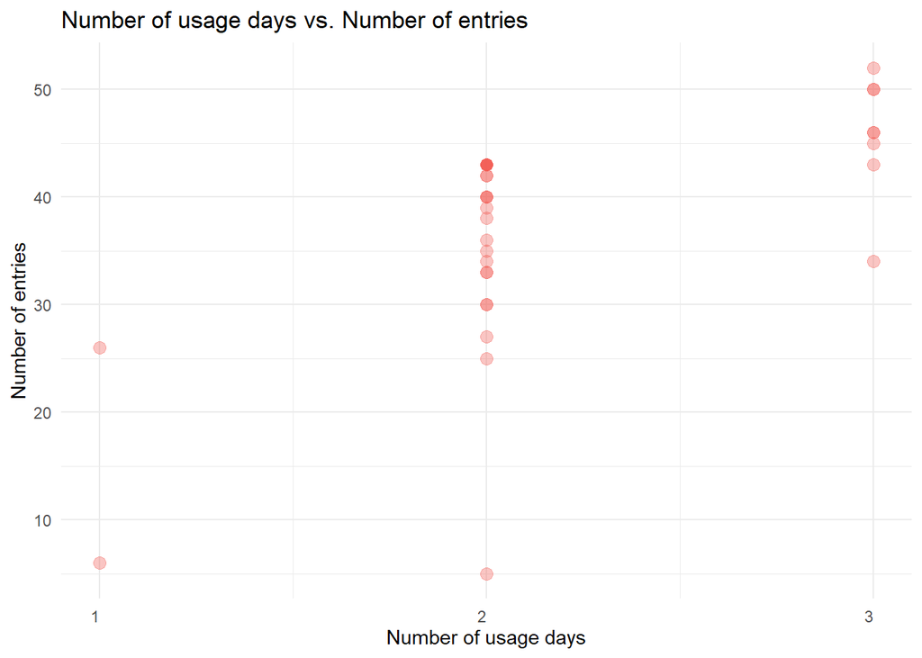

```r
chart_3 <- ggplot(sums_by_id, aes(x = count_activity_dates, y = count_by_id)) +
  geom_point(color = rgb(242, 92, 84, maxColorValue = 255, alpha = 90), size = 3) +
  scale_x_continuous(breaks = seq(
    round(min(sums_by_id$count_activity_dates)),
    round(max(sums_by_id$count_activity_dates)),
    by = 1
  )) +
  labs(
    title = "Number of usage days vs. Number of entries",
    x = "Number of usage days",
    y = "Number of entries"
  ) +
  theme_minimal() +
  theme(axis.text.x = element_text(angle = 0, vjust = 0.5, hjust = 1))

chart_3
```

```r
ggsave("entries_vs_days.jpeg", plot=chart_3, path = '~/bellabeat_project/Figures')

cor(sums_by_id$count_by_id, sums_by_id$count_activity_dates)
```

```
## [1] 0.6004343
```

There is a strong correlation between how many days someone used the device and how many entries were made.

### Correlation between number of entries and total steps

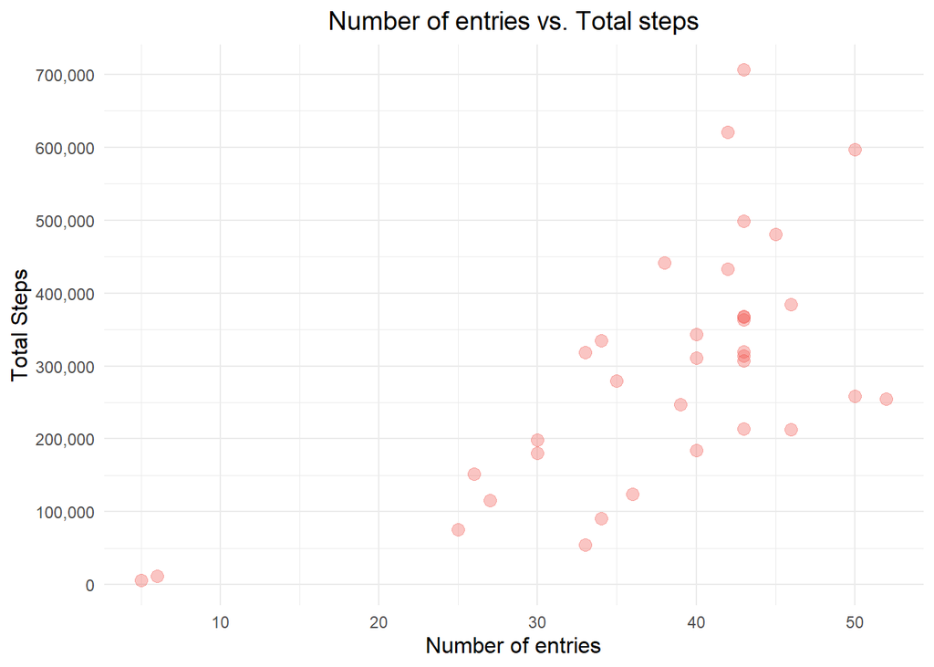

```r
chart_4 <- ggplot(sums_by_id, aes(x = count_by_id, y = total_steps_by_id)) +
  geom_point(color = rgb(242, 92, 84, maxColorValue = 255, alpha = 90), size = 3) +
  scale_y_continuous(
    breaks = seq(
      round(min(sums_by_id$total_steps_by_id), -5),
      round(max(sums_by_id$total_steps_by_id), -5),
      by = 100000
    ),
    labels = scales::comma
  ) +
  labs(
    title = "Number of entries vs. Total steps",
    x = "Number of entries",
    y = "Total Steps"
  ) +
  theme_minimal() +
  theme(
    axis.text.y = element_text(size = 9, hjust = 1),
    axis.title = element_text(size = 12),
    plot.title = element_text(hjust = 0.5, size = 14)
  )

chart_4
```

```r
ggsave("entries_vs_steps.jpeg", plot=chart_4, path = '~/bellabeat_project/Figures')

cor(sums_by_id$total_steps_by_id, sums_by_id$count_by_id)
```

```
## [1] 0.64878
```